# Categories, tables, and grouping

Social and Cultural Analytics (7AAVBCS5)

Dr Mark J. Hill · mark.j.hill@kcl.ac.uk

## Lecture plan

- **Part 0:** Classification as an analytical problem
- **Part I:** Categorical variables and the consequences of banding
- **Part II:** What frequency tables and crosstabs count
- **Part III:** Grouped summaries and defensible claims
- **Part IV:** Live coding and exercises

We will use London venue records and individual bike hires to learn the pandas methods and interpret their results.

## Key learning outcomes

By the end of this week, you should be able to:

- distinguish nominal and ordinal categorical variables
- create frequency tables with `value_counts()`
- include and interpret missing values in tables
- create crosstabs and choose the correct percentage margin
- use `groupby()` to summarise numbers by categories
- explain how counts, rates and denominators affect cultural interpretation
- assess how classification and repeated entries limit a count of places

# Part 0: Why categories matter

1. **Start with the question:** what counts as a cultural venue?
2. **Examine the labels:** how were the categories defined, and for what purpose?
3. **Check the records:** can one venue appear under several labels?
4. **Define the claim:** what does this file include, and what can its counts tell us?

## From individual records to patterns

**Research question:** How is London’s recorded cultural infrastructure distributed across venue types and boroughs?

The file has **4,434 records**, organised by 26 venue types and 33 borough areas.

However, one thing we need to check with any data is whether any of it is duplicated.

```python
import pandas as pd
venues = pd.read_csv("../../data/london_cultural_venues_2023.csv")

print("Repeated row IDs:", venues["venue_id"].duplicated().sum())
print("Repeated name/borough pairs:", venues.duplicated(
    subset=["name", "borough_name"]
).sum())
```

```
Repeated row IDs: 0
Repeated name/borough pairs: 884
```

One place can appear in several category records. We will check that overlap before treating a count as a count of distinct venues.

## One venue, several possible labels

The [**100 Club**](https://en.wikipedia.org/wiki/100_Club), located at 100 Oxford Street. It appears under three labels in our London file:

- `Music nightclubs`
- `Music venues all`
- `Music venues grassroots`

These labels describe different aspects of the same place. Counting the three entries as three separate venues would turn a classification decision into a geographical finding.

[figure not shown]

## Classification as infrastructure

In *Sorting Things Out* (1999), Bowker & Star explain how classifications organise routines in our lives: forms require a label, databases store it, and later reports add up the labelled records.

These sorting practices are artificial, but they end up structuring our lives.

The most imfamous example for their book is “The Case of Race Classification and Reclassification under Apartheid” - reporting rules that could radically impact the lives of citizens based on *ad hoc* (and made up) racial categories.

In the London file, `venue_type` determines which entries enter a music count. `borough_name` determines which entries enter Camden’s total. A later analyst inherits those decisions even if they did not choose them.

**Classification becomes infrastructure when these decisions become the ordinary machinery of counting and comparison.**

[figure not shown]

## Classification in practice: the 26 venue labels

Bowker & Star give three properties as an **abstract definition** of classification. They immediately explain that none of the working systems they studied satisfies all three.

| Abstract property | Evidence in the London labels | What this helps us investigate |
| --- | --- | --- |
| Consistent principles | Function, community, craft and production stage coexist in one list. | Which purposes do these different ways of sorting serve? |
| Mutual exclusivity | The 100 Club appears in three music categories. | How does multiple membership affect a count of places? |
| Completeness within a domain | The file has 26 selected types, with no dedicated park or community-hall category. | What does its policy scope include, and what claims fall outside it? |

**Departures from the abstract model are normal.** The analytical interest lies in how people make categories work, handle awkward cases and live with their consequences.

## The overlap is visible in the records

To check whether the 100 Club records refer to the same property, we use `uprn`: the [**Unique Property Reference Number**](https://en.wikipedia.org/wiki/Unique_Property_Reference_Number). It is an official identifier for an addressable location, rather than a dataset row or the business using that location.

```python
club = venues.loc[venues["name"] == "100 Club"]
club[["venue_type", "uprn", "venue_id"]]
```

|  | venue_type | uprn | venue_id |
| --- | --- | --- | --- |
| 4256 | Music nightclubs | 10033540054 | cim2023_3891 |
| 4294 | Music venues all | 10033540054 | cim2023_3986 |
| 4346 | Music venues grassroots | 10033540054 | cim2023_4329 |

The same named place and property identifier occur in three categories. The categories overlap at the level of places, even though each row has only one label.

## Counting records and counting places

The 100 Club example gives us **three records of one named venue**. The three labels describe different aspects of that venue.

`Music venues all` is the name of the dataset’s broad music-venue category. `Music venues grassroots` is a separate category using grassroots criteria. “All” is part of the label.

For the tables that follow, **a count means a count of rows in the file**.

## Completeness within a defined scope

This does not make the dataset bad!

A dataset is (and can be) complete only in relation to **what it sets out to include**.

For example, the GLA’s `Libraries` definition includes public and community libraries, but excludes libraries attached to higher education institutions.

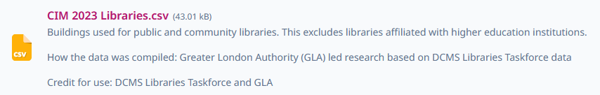

GLA Libraries definition and data-source credit

| Example | How to interpret it |
| --- | --- |
| A university library has no record in this category | It is outside the stated definition. |
| A public library meets the definition but has no record | There is a gap within the intended coverage. |

Both affect what we can say about London, and may be important to our RQs. However, only the second is an omission within that definition.

## How “grassroots music venue” became a category

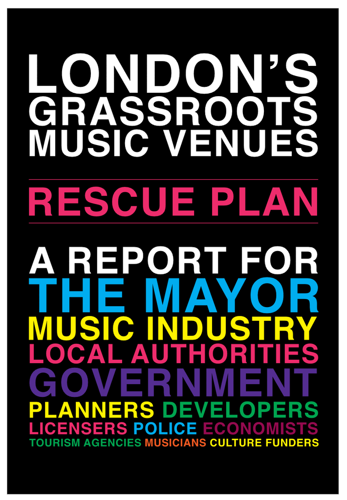

[Link to the 2015 report](https://www.london.gov.uk/sites/default/files/londons_grassroots_music_venues_-_rescue_plan_-_october_2015.pdf)

A **grassroots music venue** is defined partly by its cultural role: music is central to its programme, it supports artists, and it has a place in a local music community.

The Mayor’s Music Venues Taskforce, chaired by Mark Davyd of Music Venue Trust, set out the definition in its **October 2015 Rescue Plan** (pp. 34–36).

A shared definition makes it possible to identify a group of venues, document threats to them and argue for support. The category therefore serves a practical purpose beyond describing a building.

The Rescue Plan also argued for protection. **Agent of Change** is a concrete example: under the **2021 London Plan, Policy D13**, new flats beside an existing venue must address its noise through measures such as sound insulation.

## Every count is a count of a category

For each count result, keep three questions in view:

1. **What did we count?** Here, venue records. The 100 Club contributes three records, even though it is one venue.
2. **How were the categories defined?** For example, which spaces qualify as libraries, or which locations fall within a borough’s boundaries?
3. **What did we divide by?** All records, records in one borough, records of one type, or residents.

The next sections show how to make those counts and comparisons in pandas.

# Part I: Categorical data

1. **Distinguish the types:** categories with no inherent order, and categories with an order.
2. **Inspect the labels:** store categorical data in pandas and examine its possible values.
3. **Create and compare ordered bands:** classify borough rates as Low, Medium or High.
4. **Switch to individual hires:** create a weekday/weekend category for a new question.

## Categorical data: **Nominal**

Categorical variables represent **categories or groups**.

**Nominal** variables represent qualitative differences, with **no inherent order**. For example:

- Music genre: rock, hip-hop, classical.
- Phone operating system: iOS, Android.
- Venue type: Libraries, Theatre, Archives.

The categories are names, not numerical measurements. We can count them, but cannot calculate a meaningful average of their labels.

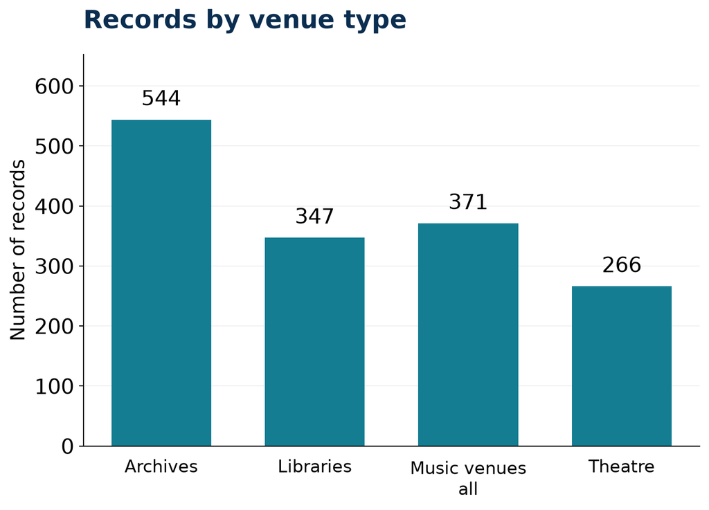

Four selected types from our London file. **Bar heights count records; the labels have no ranking.**

## Categorical data: **Ordinal**

Categorical variables represent **categories or groups**.

**Ordinal** variables have a meaningful **order, ranking or sequence**. For example:

- Highest qualification: high school, bachelor’s, master’s, PhD.
- Agreement (right): “I can easily reach cultural venues from where I live.” with responses coded strongly disagree, disagree, neither agree nor disagree, agree, strongly agree.

We can code these categories with numbers, such as 1–5. The order is meaningful; **equal numerical gaps are not guaranteed**.

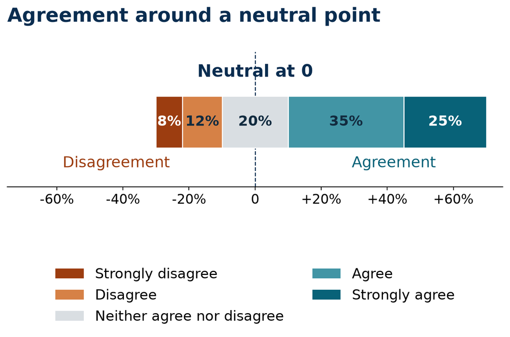

**100 fictional responses.** Neutral is centred on zero; disagreement sits to the left and agreement to the right.

## Python’s categorical type

Often when working with categorical data we convert it into a specific “category” datataype (dtype). In our data, that would mean turning the venue-type column to pandas’ `category` dtype.

```python
venues["venue_type"] = venues["venue_type"].astype("category")
print(venues["venue_type"].cat.categories)
```

```
Index(['Archives', 'Artists workspaces', 'Arts centres', 'Cinemas',
       'Commercial galleries', 'Creative coworking desk space',
       'Creative workspaces', 'Dance performance venues',
       'Dance rehearsal studios', 'Fashion and design', 'Jewellery design',
       'LGBTQ venues', 'Libraries', 'Makerspaces', 'Making and manufacturing',
       'Museums and public galleries', 'Music nightclubs',
       'Music recording studios', 'Music rehearsal studios',
       'Music venues all', 'Music venues grassroots',
       'Prop and costume making', 'Set and exhibition building',
       'Textile design', 'Theatre', 'Theatre rehearsal studios'],
      dtype='str')
```

1. Saves memory
2. Can make operations faster
3. Makes the meaning explicit, including order
4. Preserves categories with zero observations: **This means tables and plots can show categories with a count of zero rather than omitting them entirely.**

`.astype("category")` changes how the column is stored. `.cat.categories` shows the category list.

## Essential operations in pandas

Use `.cat` to work with the categories of a pandas categorical column:

| Attribute / method | What it does |
| --- | --- |
| `venues["venue_type"].cat.categories` | Shows all possible categories. |
| `venues["venue_type"].cat.codes` | Shows the internal numeric code for each recorded value. |
| `venues["venue_type"].cat.rename_categories()` | Changes the names of existing categories. E.g., `venues["venue_type"].cat.rename_categories({"Libraries": "Public and community libraries"})` |
| `venues["venue_type"].cat.add_categories()` | Adds possible categories, even if no records use them yet. E.g., `venues["venue_type"].cat.add_categories(["Other"])` |
| `venues["venue_type"].cat.remove_unused_categories()` | Removes categories that no records currently use. |

For example, `venues["venue_type"].cat.categories` lists the possible labels. `venues["venue_type"].nunique()` counts observed labels; `venues["venue_type"].value_counts()` counts records with each label.

## Notes 1 and 2: codes are not values and order is not assumed

```python
likert = pd.Series(["Disagree", "Neutral", "Agree"]).astype("category")
print("internal codes:", list(likert.cat.codes))
print("string values:", list(likert.astype("string")))
```

```
internal codes: [1, 2, 0]
string values: ['Disagree', 'Neutral', 'Agree']
```

The labels contain strings representing an oder. `.cat.codes` returns their positions in the category list: 1, 2 and 0.

```python
numbers = pd.Series(["10", "20", "30"]).astype("category")
print("internal codes:", list(numbers.cat.codes))
print("numeric values:", list(numbers.astype("string").astype(int)))
```

```
internal codes: [0, 1, 2]
numeric values: [10, 20, 30]
```

The labels contain 10, 20 and 30. `.cat.codes` returns their positions in the category list: 0, 1 and 2.

## Note 3: unused categories remain

```python
havering = venues.loc[venues["borough_name"] == "Havering"]
print("possible labels:", len(havering["venue_type"].cat.categories))
print("observed types:", havering["venue_type"].nunique())
havering["venue_type"] = havering["venue_type"].cat.remove_unused_categories()
print("labels after removal:", len(havering["venue_type"].cat.categories))
```

```
possible labels: 26
observed types: 9
labels after removal: 9
```

Filtering keeps **26 possible labels**, although only **9 are recorded** in Havering’s rows. Removing unused labels changes the category list, not the rows.

## Making ordinal categories from borough rates

We can turn a numerical rate into an **ordered category**, just as our agreement responses had an order.

For our London data, we will group boroughs by their recorded venue rates (per 10k residents) into three bands:

| Band | Records per 10,000 residents |
| --- | --- |
| Low | below 5 |
| Medium | 5 to below 15 |
| High | 15 or more |

These cut points are our teaching choice. They are not official standards of cultural provision. This is another example of the way categories are human constructions!

## The borough data for our bands

Load the borough context file. **One row now describes one borough area**, rather than one venue record.

```python
borough_context = pd.read_csv(
    "../../data/london_cultural_infrastructure_2023_borough_context.csv"
)
borough_context[["borough_name", "venues_per_10k_residents"]].head()
```

|  | borough_name | venues_per_10k_residents |
| --- | --- | --- |
| 0 | Westminster | 28.32 |
| 1 | Camden | 20.36 |
| 2 | Hackney | 15.34 |
| 3 | Southwark | 9.95 |
| 4 | Tower Hamlets | 10.38 |

`venues_per_10k_residents` is a prepared rate: recorded rows per 10,000 residents. It uses 2015 population with the 2023 venue release.

## Ordered categories (i.e., ordinal variables)

First assign labels using conditions, as in Weeks 3–4. Then tell pandas their order.

```python
# Create a new column for our ordinal variable
borough_context["rate_band"] = ""

# Use the existing date (venues_per_10k_residents) to assign the rating to the new column
borough_context.loc[borough_context["venues_per_10k_residents"] < 5, "rate_band"] = "Low"
borough_context.loc[(borough_context["venues_per_10k_residents"] >= 5)
    & (borough_context["venues_per_10k_residents"] < 15), "rate_band"] = "Medium"
borough_context.loc[borough_context["venues_per_10k_residents"] >= 15, "rate_band"] = "High"

# Turn the column into a categorical dtype and make them ordered
borough_context["rate_band"] = borough_context["rate_band"].astype("category")
borough_context["rate_band"] = borough_context["rate_band"].cat.set_categories(
    ["Low", "Medium", "High"], ordered=True
)
print(borough_context["rate_band"].cat.categories)
print("ordered:", borough_context["rate_band"].cat.ordered)
```

```
Index(['Low', 'Medium', 'High'], dtype='str')
ordered: True
```

`.cat.set_categories(..., ordered=True)` sets **Low < Medium < High**.

## The same rates, different bands

`pd.qcut()` (quantile cut) sorts the boroughs by rate and divides them into approximately equal-sized groups. Here, `q=3` requests three groups.

```python
borough_context["quantile_band"], quantile_edges = pd.qcut(
    borough_context["venues_per_10k_residents"],
    q=3, labels=["Low", "Medium", "High"], retbins=True,
)
band_counts = pd.DataFrame({
    "Fixed thresholds": borough_context["rate_band"].value_counts(sort=False),
    "Quantile bands": borough_context["quantile_band"].value_counts(sort=False),
})
print(band_counts)
```

```
        Fixed thresholds  Quantile bands
Low                   22              11
Medium                 7              11
High                   4              11
```

## “Low” describes a rule as well as a borough

**Where do the labels change?** Cultural venue entries per 10,000 residents:

|  | Band | Fixed rule | Quantile rule |
| --- | --- | --- | --- |
| 0 | Low | Below 5 | Up to 1.6333 |
| 1 | Medium | 5 to below 15 | Above 1.6333 to 4.9833 |
| 2 | High | 15 or above | Above 4.9833 |

|  | borough_name | venues_per_10k_residents | rate_band | quantile_band |
| --- | --- | --- | --- | --- |
| 7 | Lewisham | 5.05 | Medium | High |
| 23 | Hillingdon | 1.69 | Low | Medium |

Lewisham’s **5.05** is borderline low/medium with the fixed threshold but high with the quantile threshold.

## London’s hire bikes: Santander Cycles

**Santander Cycles** is London’s docked bike-hire scheme. Hire a bike at a docking station and return it to a docking station after use.

Our data contains individual **bike hires**.

**One trip record = one recorded hire = one row**, with a start station, an end station, and a duration. That is, this is **non-aggregated** data.

[figure not shown]

## Our bike-hire extract: one record per hire

**443,539 hires starting on 16–31 July 2025**, across **12 borough areas**. This is a 16-day extract, not the whole year.

```python
trips = pd.read_csv("../../data/tfl-bike-hire/bike_trips_16-31Jul2025_with_borough.csv")
trips.head()
```

|  | trip_id | start_time | date | weekday | start_station | start_borough | end_station | end_borough | bike_model | duration_min |
| --- | --- | --- | --- | --- | --- | --- | --- | --- | --- | --- |
| 0 | 150869175 | 2025-07-31 23:59:00 | 2025-07-31 | Thursday | Lambeth North Station, Waterloo | Lambeth | Kennington Road Post Office, Oval | Lambeth | CLASSIC | 5.5 |
| 1 | 150869176 | 2025-07-31 23:59:00 | 2025-07-31 | Thursday | Falkirk Street, Hoxton | Hackney | Hoxton Street, Hoxton | Hackney | CLASSIC | 12.4 |
| 2 | 150869177 | 2025-07-31 23:59:00 | 2025-07-31 | Thursday | Breams Buildings, Holborn | City of London | Hardwick Street, Clerkenwell | Islington | CLASSIC | 8.6 |
| 3 | 150869168 | 2025-07-31 23:58:00 | 2025-07-31 | Thursday | Warren Street Station, Euston | Camden | Killick Street, King's Cross | Islington | CLASSIC | 17.3 |
| 4 | 150869169 | 2025-07-31 23:58:00 | 2025-07-31 | Thursday | British Museum, Bloomsbury | Camden | Haggerston Road, Haggerston | Hackney | CLASSIC | 18.3 |

We are going to create a **weekday/weekend category** cetegorical variableusing the existing `weekday` column.

## Create a temporal category: weekday or weekend?

**Question:** Are recorded hires longer on weekdays or at weekends?

To compare durations, first create the groups using the existing `weekday` labels:

```python
# Create a new column and populate it with "Weekday" for every row
trips["day_type"] = "Weekday"

# Use conditionals to replace "Weekday" with "Weekend" for Saturdays and Sundays.
trips.loc[
    (trips["weekday"] == "Saturday") | (trips["weekday"] == "Sunday"),
    "day_type",
] = "Weekend"

# Turn the column into a "category" datatype
trips["day_type"] = trips["day_type"].astype("category")

# Check the data
print(trips["day_type"].cat.categories)
```

```
Index(['Weekday', 'Weekend'], dtype='str')
```

`|` means **or** between conditions; `.loc[condition, "column"] = value` assigns the label to matching hires.

**Weekday/weekend is nominal.** The labels distinguish groups; neither is a higher rank.